# data scan

Jake

May 11, 2016

## Set up workspace

1. Make sure this .Rmd file is in the folder that has your data.
2. Set your working directory. This is the location of the data you wish to scan. Make sure you use change the backslashes of the file location (default on Windows) to forward slashes.
3. If you want to do exploratory mapping, edit the chunk at the end of the script and replace “” with the name of the variables you want to map (ex: colorField = NAME not colorfiled = “NAME”)

```r
setwd("J:/Portfolio/R Tools")

fileName <- "Commercial_Corridors_fixed"  #exclude extension
fileType <- ".dbf"     # supports .csv, .dbf, .txt, be sure to include '.'

#What are X & Y coord field names?
X <- "longitude"
Y <- "latitude"

# where do you want to map? Use lower case
area_map <- map_data("county")%>%
            filter(region == "pennsylvania",
                   subregion == "philadelphia")

#for countries
#data(world.cities)
#area_map <- data.frame(map("world", "Tanzania", plot=FALSE)[c("x","y")])%>%
#            rename(long = x, lat = y)%>%mutate(subregion = "Tanzania")
```

### Overview of Data

Number of rows: 274

| Name | Class | MaxChar | Missing | pMissing | Complete | pComplete | Unique | Index | X1 | X2 |
| --- | --- | --- | --- | --- | --- | --- | --- | --- | --- | --- |
| NAME | cha | 47 | 0 | 0 | 274 | 100 | 274 | 1 | Broad and Snyder | Pennsport Mall/South |
| P_DIST | cha | 13 | 1 | 0 | 273 | 100 | 19 | 0.97 | South | South |
| CRM_ORG | cha | 59 | 188 | 69 | 86 | 31 | 47 | 0.96 | Office of Business |  |
| PHYS_CHAR | cha | 27 | 87 | 32 | 187 | 68 | 6 | 0.68 | Mixed Character | Mixed Character |
| COND_PUB | cha | 9 | 89 | 32 | 185 | 68 | 5 | 0.66 | Good | Good |
| COND_PRIV | cha | 9 | 89 | 32 | 185 | 68 | 5 | 0.68 | Fair | Good |
| STORE_MIX | cha | 9 | 89 | 32 | 185 | 68 | 5 | 0.71 | Fair | Fair |
| STAGE | cha | 12 | 89 | 32 | 185 | 68 | 5 | 0.67 | Stable | Declining |
| AGE | int | 4 | 87 | 32 | 187 | 68 | 20 | 0.93 | 1890 | 1980 |
| SURVEY_YEA | int | 4 | 86 | 31 | 188 | 69 | 6 | 0.66 | 2014 | 2014 |

[output cut: 7 more lines]

This report tells you the class and maximum character length for each column in the data. The table then tells the number and percentage of records that are missing values as well as those that are complete. The ‘Unique’ column tells how many unique values exist for that variable and the ‘Index’ uses a Gini index score to asses the diversity of the records. The last two columns ‘X1’ & ‘X2’ are the first 20 characters of rows 1 and 2 of the data you are analyzing.

### Consider Removing (% Missing > 50%)

| Name | Class | MaxChar | Missing | pMissing | Complete | pComplete | Unique | Index | X1 | X2 |
| --- | --- | --- | --- | --- | --- | --- | --- | --- | --- | --- |
| CRM_ORG | cha | 59 | 188 | 69 | 86 | 31 | 47 | 0.96 | Office of Business | NA |

# Quick Plots

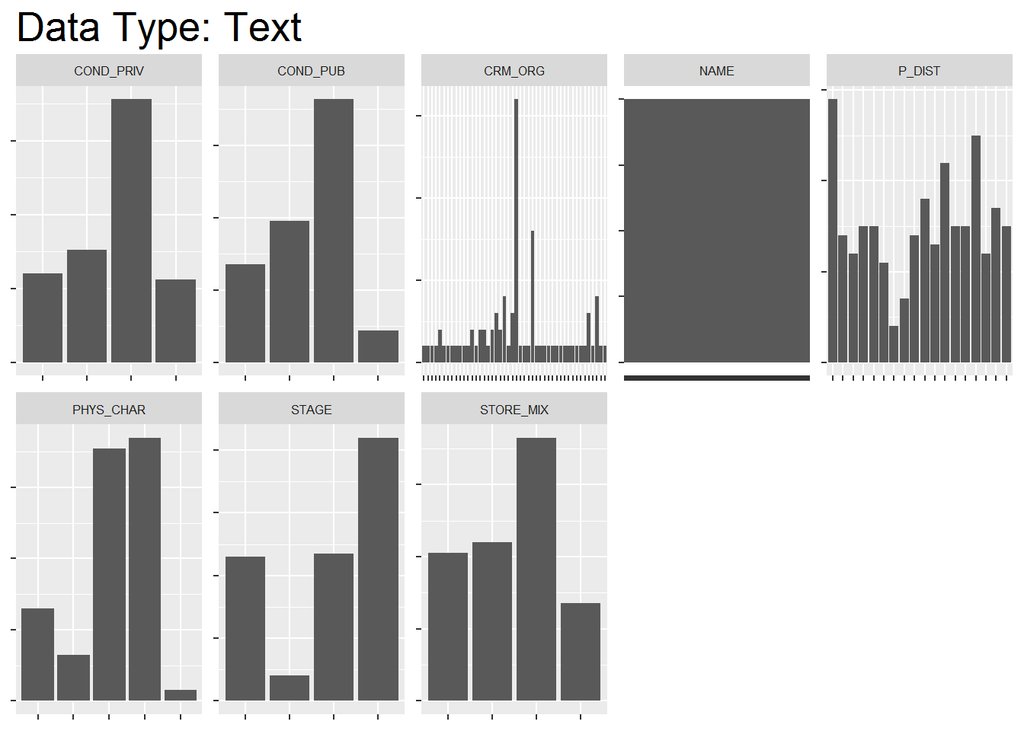

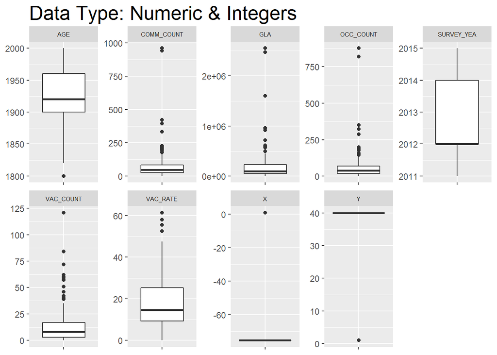

# Correlation Matrix

### (integer & numeric only)

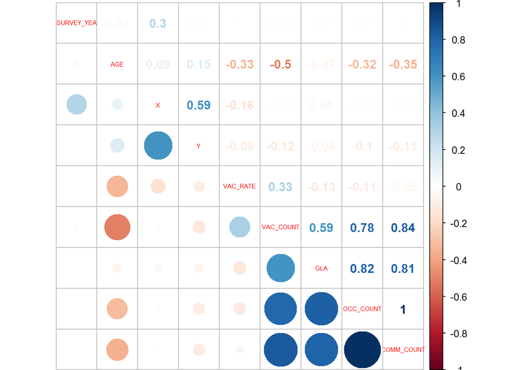

### Consider for Thematic Maps (Diversity Index > 0.2, Unique <=20)

| Name | Class | MaxChar | Missing | pMissing | Complete | pComplete | Unique | Index | X1 | X2 |
| --- | --- | --- | --- | --- | --- | --- | --- | --- | --- | --- |
| P_DIST | cha | 13 | 1 | 0 | 273 | 100 | 19 | 0.97 | South | South |
| AGE | int | 4 | 87 | 32 | 187 | 68 | 20 | 0.93 | 1890 | 1980 |
| STORE_MIX | cha | 9 | 89 | 32 | 185 | 68 | 5 | 0.71 | Fair | Fair |
| PHYS_CHAR | cha | 27 | 87 | 32 | 187 | 68 | 6 | 0.68 | Mixed Character | Mixed Character |
| COND_PRIV | cha | 9 | 89 | 32 | 185 | 68 | 5 | 0.68 | Fair | Good |
| STAGE | cha | 12 | 89 | 32 | 185 | 68 | 5 | 0.67 | Stable | Declining |
| COND_PUB | cha | 9 | 89 | 32 | 185 | 68 | 5 | 0.66 | Good | Good |
| SURVEY_YEA | int | 4 | 86 | 31 | 188 | 69 | 6 | 0.66 | 2014 | 2014 |

# CUSTOMIZED: MAPS

```r
##Create custom maps
# Use fields from data after '=' sign

with(data, area_points(colorField  = STAGE
                       , sizeField = GLA
                       , textField = NAME
                       , title     = "STAGE"))
```

[interactive chart not shown]

```r
with(data, area_points(colorField  = PHYS_CHAR
                       , sizeField = GLA
                       , textField = NAME
                       , title     = "PHYS_CHAR"))
```

[interactive chart not shown]

```r
with(data, area_points(colorField  = COND_PUB
                       , sizeField = GLA
                       , textField = NAME
                       , title     = "COND_PUB"))
```

[interactive chart not shown]

```r
with(data, area_points(colorField  = SURVEY_YEA
                       , sizeField = GLA
                       , textField = NAME
                       , title     = "SURVEY_YEA"))
```

[interactive chart not shown]

```r
with(data, area_points(colorField  = P_DIST
                       , sizeField = GLA
                       , textField = NAME
                       , title     = "P_DIST"))
```

[interactive chart not shown]

```r
with(data, area_points(colorField  = STORE_MIX
                       , sizeField = GLA
                       , textField = NAME
                       , title     = "STORE_MIX"))
```

[interactive chart not shown]